# Variáveis Instrumentais

## Introdução

O risco de ser convocado para uma guerra muda as atitudes políticas de quem o enfrenta? A pergunta atravessa décadas de debate sobre formação política e juventude. A resposta tentadora seria comparar quem foi convocado com quem não foi, ou quem combateu com quem não combateu. Mas essas populações diferem em classe, escolaridade, região e disposições prévias: quem se alistou voluntariamente, quem ficou de fora por dispensa estudantil ou médica, quem pôde pagar pela faculdade para evitar a convocação. Uma simples diferença de média confunde o efeito do risco com tudo que distinguia os indivíduos antes dele.

Em 1º de dezembro de 1969, no auge da Guerra do Vietnã, o governo americano sorteou em televisão nacional a ordem de convocação dos jovens em idade de servir. Cada data de nascimento recebeu um número de 1 a 366; números baixos eram chamados primeiro, números altos escapariam. Erikson and Stoker (2011) usam o número sorteado como instrumento para a *vulnerabilidade* à convocação, em vez de para o serviço militar efetivo: o que importa é a expectativa de poder ser chamado a servir, antes mesmo de o chamado se concretizar. O número é aleatório por design, afeta a probabilidade percebida de ser convocado, e não tem motivo plausível para afetar atitudes décadas depois por outro canal. O resultado: jovens com números baixos se tornaram mais antiguerra, mais liberais e mais propensos a se identificar com o Partido Democrata. O efeito persiste em entrevistas décadas depois e não é mediado pelo serviço militar efetivo: a transformação política veio do risco percebido, não do combate.

Essa é a lógica das variáveis instrumentais. O restante do capítulo desenvolve as condições sob as quais ela funciona: começa pela formulação em DAGs, passa pelo modelo estrutural e pelos mínimos quadrados em dois estágios, e termina sob heterogeneidade de efeitos, em que VI identifica o LATE, o efeito médio sobre quem responde ao instrumento.

Considere o seguinte DAG canônico de Variáveis Instrumentais:

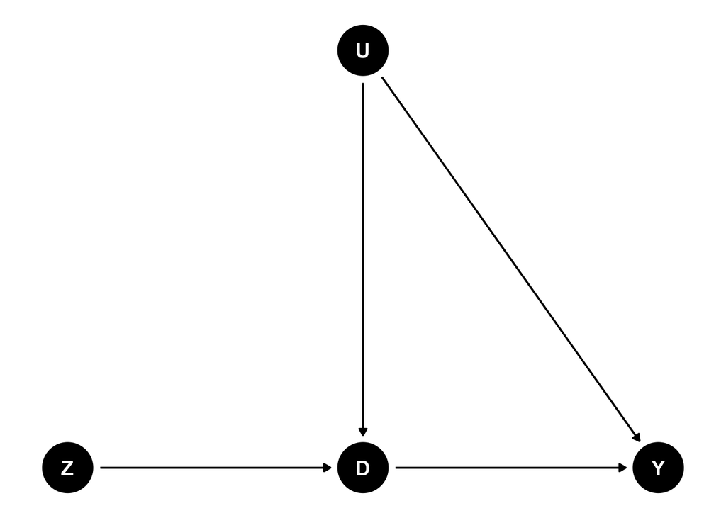

Nós vemos que o efeito causal do tratamento $D$ é confundido pela variável não observada $U$, já que temos um *backdoor* aberto. Porém, a variável $Z$ não tem nenhum caminho aberto para $Y$ exceto via $D$, isto é, $D$ é um mediador do efeito causal de $Z$.

Do ponto de vista não paramétrico (DAGs), dizemos que a variável $Z$ é uma **candidata** a variável instrumental (IV) se:

1. $Z$ está conectado a $D$ no grafo original. Condição de **relevância**.
2. No grafo em que a seta de $D$ para $y$ é removida, $Z$ é d-separado de $Y$. **Exclusion Restriction**.
3. A variável instrumental $Z$ não compartilha causa comum com $Y$, incluindo, portanto, não ser descendente de $D$. **Causa comum**.

Em alguns casos, é necessário controlar para um conjunto de covariáveis $X$ para que a segunda condição seja satisfeita; chamamos isso de IV condicional. Note também que dizemos que $Z$ é apenas uma **candidata** a instrumento porque as três condições acima, embora necessárias, não são suficientes — discutiremos adiante o que mais é preciso (em particular, monotonicidade, sob heterogeneidade de efeitos).

A literatura econométrica às vezes formula a condição 3 dizendo que $Z$ deve *causar* $D$. A direção da implicação é correta: se $Z$ causa $D$ e é tratado como exógeno, segue-se que $Z$ e $Y$ não compartilham causa comum, validando a condição 3. A volta é falsa: VI não exige que $Z$ cause $D$. Manter as condições 2 (exclusão) e 3 (causa comum) separadas torna esse ponto visível, porque a condição 2 fecha caminhos diretos de $Z$ para $Y$ e a condição 3 fecha caminhos por confundimento, sem que nenhuma das duas exija causalidade $Z \to D$. O DAG abaixo mostra um caso em que $Z$ não causa $D$ e ainda assim é VI candidata: condicionando em $V_3$, um collider entre $Z$ e $D$, induz-se a correlação que satisfaz a relevância sem violar a condição 3.

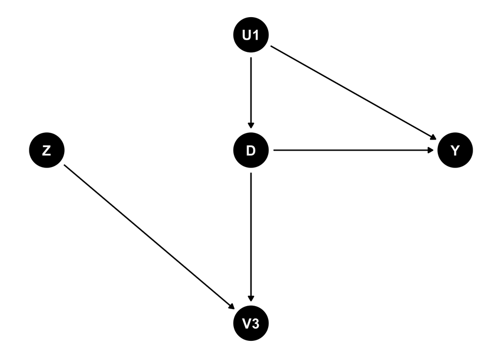

Do mesmo jeito, se $V_3$ for causa comum de $Z$ e $D$, não controlar para ela torna $Z$ admissível como VI.

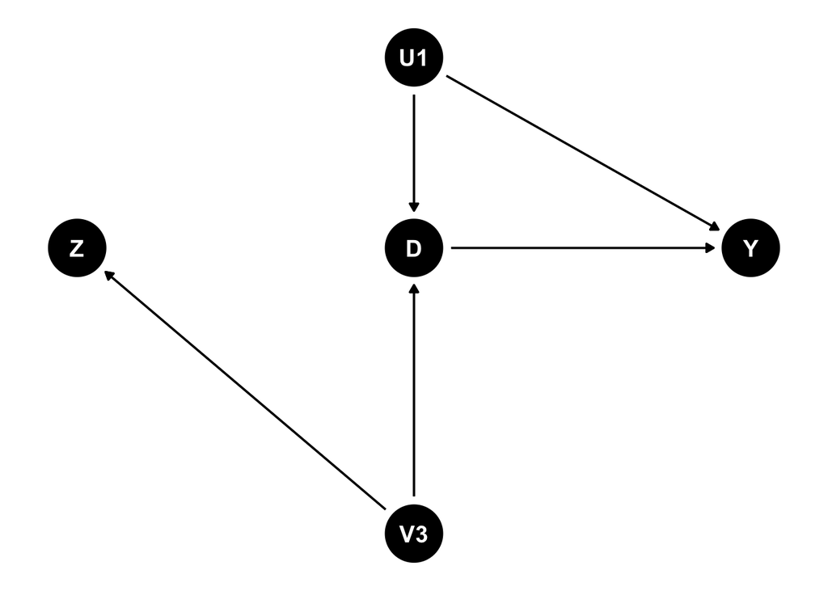

Será que $Z$ pode ser uma IV no DAG abaixo?

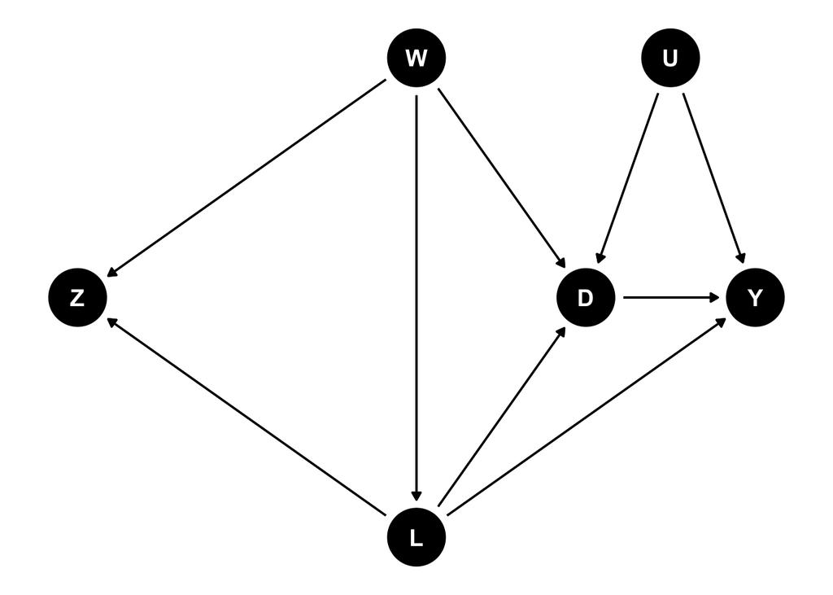

Vamos verificar as condições. É fácil ver que $Z$ está conectado a $D$, já que temos dois caminhos abertos, um via $W$ e outro via $L$ (e ainda um via $W$ via $L$). Portanto, a primeira condição está satisfeita. Note que se eu controlar simultaneamente para $W$ e $L$, então eu fecho todos os caminhos abertos.

Com relação à segunda condição, remover a flecha de $D$ para $Y$ é, efetivamente, ter um novo DAG:

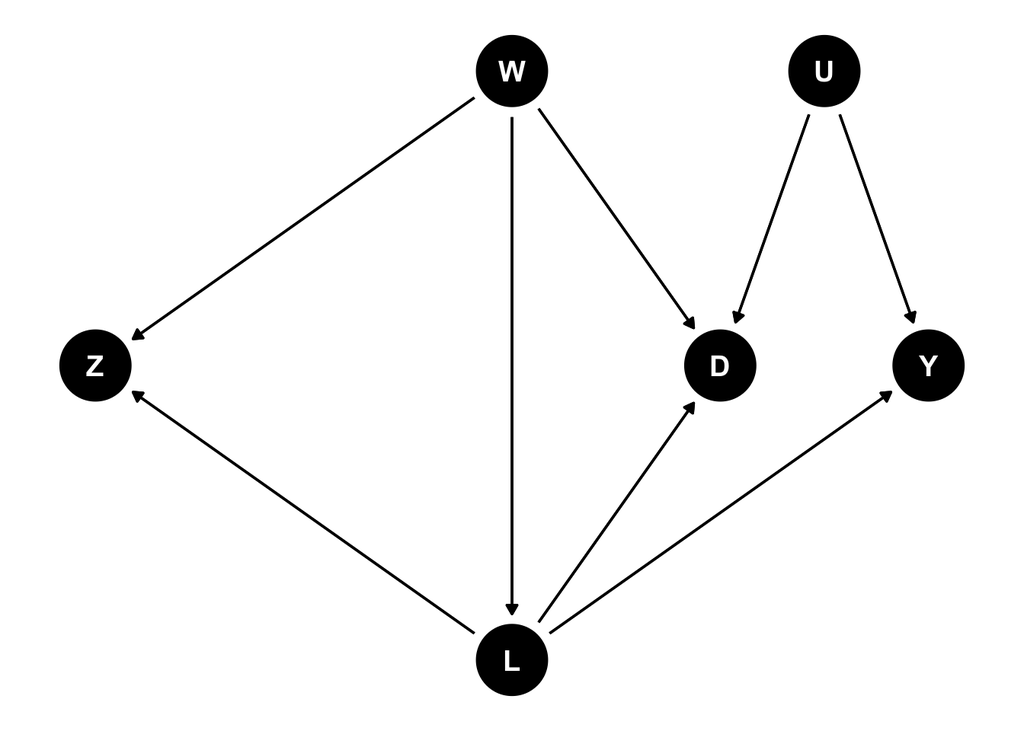

Nesse DAG, $Z$ não está d-separado de $Y$, pois existe um caminho aberto para $Y$ via $L$. Portanto, controlando para $L$ (mas não $W$), tenho um instrumento que passa nas duas condições.

Até aqui vimos as condições para que uma variável seja candidata a instrumento a partir da perspectiva de DAGs. Vejamos agora como essas condições se traduzem em um modelo estrutural paramétrico.

## IV com modelo estrutural

$$\begin{align}
y_i &= \beta D_i + \delta_2 U + e_i \\
D_i &= \delta_1 U + \pi z_i + u_i
\end{align}$$

As duas equações são estruturais: representam relações causais, não apenas associações estatísticas. Para que $\beta$ seja interpretado como o efeito causal de $D$ sobre $Y$, precisaríamos da exogeneidade do tratamento, $\mathbb{E}[e_i \mid D_i] = 0$. Essa condição falha: $D_i$ é endógeno porque $U$ aparece nas duas equações, gerando viés de variável omitida.

O instrumento $z_i$, por construção do modelo, entra na equação de $D_i$ mas não na equação de $y_i$. Essa ausência é a restrição de exclusão: $z$ está excluído do RHS da equação de $Y$. Sob este modelo, a hipótese se traduz operacionalmente em $\mathbb{E}[z_i \, e_i] = 0$, ou seja, o instrumento é não-correlacionado com o erro estrutural de $Y$. Voltamos a essa hipótese mais adiante, onde apresentamos três formulações diferentes.

Vamos supor, para simplificar, que tanto $D_i$ quanto $Z_i$ são binários.

Nós sabemos que diferença simples de média identifica o ATE da segunda equação: $\hat{\pi} = \bar{D}_{\{Z=1\}} - \bar{D}_{\{Z=0\}} = \frac{\sum_{i} z_i D_i}{\sum_{i} z_i} - \frac{\sum_{i} (1-z_i) D_i}{\sum_{i} (1-z_i)}$.

## MQO em 2 Estágios

Considere novamente o DAG canônico para IV. Como poderíamos estimar o efeito causal de $D$ sobre $Y$?

Uma possibilidade é a chamada forma reduzida, que pode ser derivada a partir da suposição de independência. Antes, vamos introduzir uma notação:

A notação $Y^{D=d,Z=z}$ indica o resultado potencial para um nível do tratamento $d$ efetivamente recebido, que pode ser $0$ ou $1$, e para um nível do *treatment assignment*, que pode ser $0$ ou $1$, para um instrumento binário.

E também temos um status potencial do tratamento (em oposição ao tratamento observado): $D^1_i$ é o status do tratamento quando $Z=1$. Similarmente, $D^0_i$ é o status do tratamento quando $Z=0$.

E aqui temos uma nova *switching equation*:

$$D_i = D^0_i + (D^1_i -
D^0_i)Z_i$$

$$\begin{align}
E\big[Y_i\mid Z_i=1\big]-E\big[Y_i\mid Z_i=0\big] & =
E\big[Y_i(D_i^1,1)\mid Z_i=1\big]-
E\big[Y_i(D_i^0,0)\mid Z_i=0\big]
\\
& = E[Y_i(D_i^1,1)] -
E[Y_i(D_i^0,0)]
\end{align}$$

O estimador é o efeito causal (total) de $Z$ sobre $Y$. Em um experimento, isso é chamado de *intent to treat*, pois se a aleatorização é o instrumento, então é o efeito causal da intenção de tratar.

```r
library(stargazer)

n <- 100000

set.seed(123)
z <- rnorm(n)
u <- rnorm(n, 0 , 3)
treatment <- rbinom(n, 1, plogis(z - u + rnorm(n, 0, 2)))

y <- 2*treatment + u

reg_vies <- lm(y ~ treatment)
reg_1s   <- lm(treatment ~ z)
reg_2s   <- lm(y ~ fitted(reg_1s))

stargazer(reg_vies, reg_1s, reg_2s,
          type = ifelse(knitr::is_html_output(), "html", "latex"),
          title = "OLS e 2SLS")
```

**OLS e 2SLS**

|  | *Dependent variable:* |  |  |
| --- | --- | --- | --- |
|  | y | treatment | y |
|  | (1) | (2) | (3) |
| treatment | -1.495*** |  |  |
|  | (0.016) |  |  |
| z |  | 0.095*** |  |
|  |  | (0.002) |  |
| fitted(reg_1s) |  |  | 1.916*** |
|  |  |  | (0.085) |
| Constant | 1.760*** | 0.499*** | 0.058 |
|  | (0.011) | (0.002) | (0.043) |
| Observations | 100,000 | 100,000 | 100,000 |
| R<sup>2</sup> | 0.085 | 0.036 | 0.005 |
| Adjusted R<sup>2</sup> | 0.085 | 0.036 | 0.005 |
| Residual Std. Error (df = 99998) | 2.453 | 0.491 | 2.558 |
| F Statistic (df = 1; 99998) | 9,283.268*** | 3,739.184*** | 505.426*** |
| *Note:* | p<0.1; p<0.05; p<0.01 |  |  |

A primeira coluna traz a regressão ingênua de $Y$ sobre $D$: o coeficiente está viesado porque $U$ afeta $D$ e $Y$ ao mesmo tempo, e a covariância induzida puxa a estimativa para longe do efeito verdadeiro $\beta = 2$ usado na simulação. A segunda coluna é o primeiro estágio: $Z$ desloca $D$ na direção esperada. A terceira coluna regrede $Y$ sobre $\hat{D}$, a parte de $D$ projetada sobre $Z$, e recupera um coeficiente próximo de $2$. A diferença entre a primeira e a terceira coluna é o viés que VI corrige.

Uma regra de bolso, baseada em Stock and Yogo (2005), diz que a estatística F da regressão do primeiro estágio deve ser maior que 10.

```r
library(tidyverse)
```

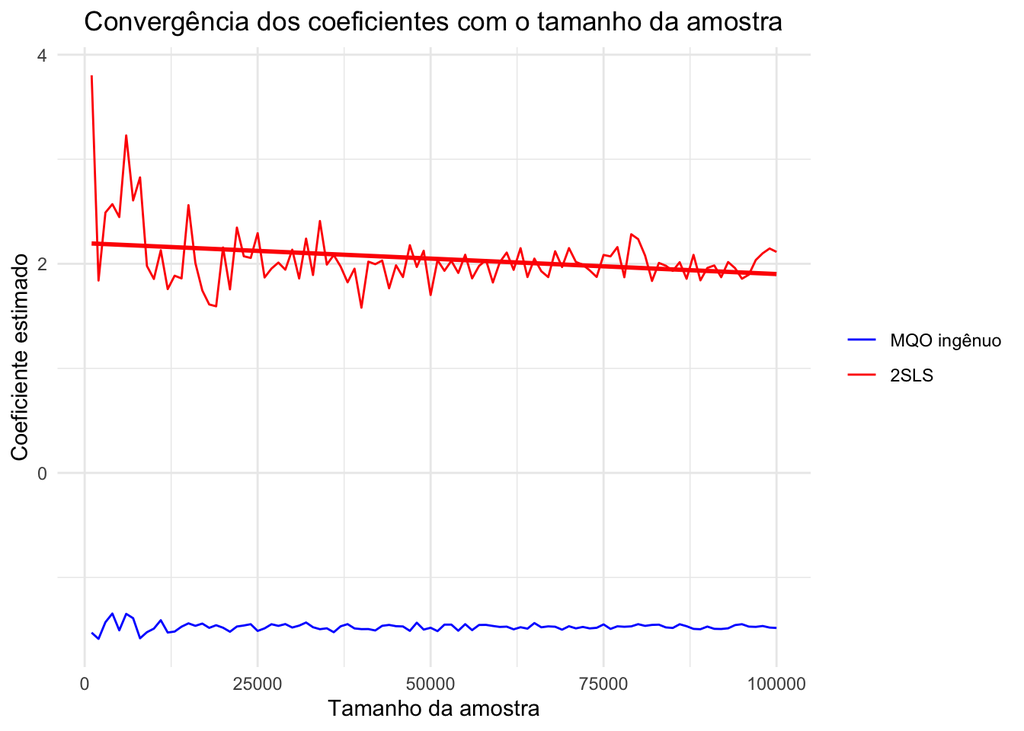

```r
library(ggplot2)

simulate_and_fit <- function(n) {
  z <- rnorm(n)
  u <- rnorm(n, 0, 3)
  treatment <- rbinom(n, 1, plogis(z - u + rnorm(n, 0, 2)))
  y <- 2 * treatment + u

  # Naive regression
  reg_vies <- lm(y ~ treatment)

  # 2SLS
  reg_1s <- lm(treatment ~ z)
  predicted_treatment <- predict(reg_1s)
  reg_2s <- lm(y ~ predicted_treatment)

  # Return coefficients
  tibble(
    naive_coef = coef(reg_vies)[2],
    tsls_coef = coef(reg_2s)[2]
  )
}


# Sample sizes to simulate
sample_sizes <- seq(1000, 100000, by = 1000)

# Use map to apply the function to each sample size
results <- tibble(sample_size = sample_sizes) %>%
  mutate(
    simulation_results = map(sample_size, simulate_and_fit)
  ) %>%
  unnest(cols = c(simulation_results))

results %>%
  pivot_longer(cols = c(naive_coef, tsls_coef), names_to = "method", values_to = "coefficient") %>%
  ggplot(aes(x = sample_size, y = coefficient, color = method)) +
  geom_line() +
  geom_smooth(data = . %>% filter(method == "tsls_coef"), method = "lm", se = FALSE, color = "red") +

  labs(
    title = "Convergência dos coeficientes com o tamanho da amostra",
    x = "Tamanho da amostra",
    y = "Coeficiente estimado",
    color = "Método"
  ) +
  theme_minimal() +
  scale_color_manual(
    values = c("naive_coef" = "blue", "tsls_coef" = "red"),
    labels = c("naive_coef" = "MQO ingênuo", "tsls_coef" = "2SLS")
  ) +
  theme(
    plot.title = element_text(hjust = 0.5),
    legend.title = element_blank()
  )
```

## Efeito heterogêneo

Os resultados anteriores supuseram que o efeito do tratamento é homogêneo: $Y^1_i - Y^0_i = \beta$ para toda unidade $i$. Quando o efeito varia entre indivíduos, o que IV identifica deixa de ser o ATE — passa a ser um efeito médio sobre um subgrupo específico, definido pelo próprio instrumento.

Para discutir efeito causal heterogêneo, vamos utilizar um estudo em ciência política (White 2019). Qual é o efeito de uma condenação por *misdemeanor* (algo como contravenção penal) sobre comparecimento eleitoral? O autor argumenta que o efeito deve variar por raça (maior para negros que brancos), de modo que o efeito causal é heterogêneo. Segundo o autor, casos são atribuídos aleatoriamente a diferentes cortes judiciais, e elas variam em sua leniência. Aqui, o tratamento é a condenação ($D_i = 1$ se condenado, $0$ caso contrário), e o instrumento é o sorteio de um juiz mais ou menos leniente.

Formalmente, o efeito causal heterogêneo é $\delta_i = Y^1_i - Y^0_i$. Nesse caso, não podemos mais estimar o efeito causal médio populacional (ATE), porque o instrumento só explica variação no tratamento para um subgrupo da população: os *compliers*. Antes de derivar o estimador, vale fixar o vocabulário.

## Tipologia de unidades

Sob um instrumento binário $Z_i \in \{0, 1\}$, cada unidade tem dois status potenciais de tratamento, $D^0_i$ (se $Z_i = 0$) e $D^1_i$ (se $Z_i = 1$). A combinação dos dois define quatro tipos:

|  | $D^0_i = 0$ | $D^0_i = 1$ |
| --- | --- | --- |
| $D^1_i = 0$ | **never-takers** | **defiers** |
| $D^1_i = 1$ | **compliers** | **always-takers** |

No estudo de White (2019):

- **Always-takers** são acusados que serão condenados qualquer que seja o juiz sorteado — em geral aqueles com forte conjunto de evidências contra si.
- **Never-takers** são acusados que serão absolvidos qualquer que seja o juiz — em geral aqueles com poucas evidências.
- **Compliers** são acusados cuja condenação responde ao instrumento: condenados se enviados ao juiz severo, absolvidos se enviados ao leniente.
- **Defiers** seriam acusados que fariam o oposto: absolvidos pelo juiz severo e condenados pelo leniente. Substantivamente, isso não faz sentido no contexto, mas teoricamente é uma possibilidade que precisa ser excluída por hipótese.

Apenas o subgrupo dos compliers fornece variação útil para identificar efeito causal a partir do instrumento. Para always- e never-takers, o instrumento não move o tratamento; para defiers, move-o na direção contrária. As suposições adicionais a seguir excluem defiers da população e isolam o efeito local sobre os compliers.

## Suposições para o LATE

### SUTVA

Resultados potenciais para a unidade $i$ não dependem do tratamento recebido por $j$. Há potencial para SUTVA ser violada no estudo de encarceramento e voto: se dois irmãos ($i$ e $j$) são acusados e um deles é preso, o tratamento de um pode impactar a probabilidade de voto do outro. White não discute explicitamente essa possibilidade. Vamos supor, porém, que SUTVA esteja garantido.

### Independência

Também chamada de *as good as random assignment* ou *no confounding for the effect of $Z$ on $Y$*: o instrumento é independente dos resultados potenciais $Y_i(d)$ e dos status potenciais de tratamento $D^z_i$. No estudo de White, a aleatorização da corte sustenta essa hipótese: é difícil imaginar variável que cause a leniência judicial e simultaneamente o comparecimento eleitoral.

Vale tornar o mapeamento entre as duas formulações de IV explícito. Cada uma das três suposições não-paramétricas vistas no início do capítulo tem uma contrapartida em resultados potenciais:

| Hipótese | DAG | Resultados potenciais |
| --- | --- | --- |
| Relevância | $Z$ conectado a $D$ no grafo original | $\mathbb{E}[D_i \mid Z_i = 1] \neq \mathbb{E}[D_i \mid Z_i = 0]$ |
| Exclusão | $Z$ d-separado de $Y$ no grafo sem $D \to Y$ | $Y_i(d, z) = Y_i(d, z')$ para todo $i, d, z, z'$ |
| Sem confundimento | $Z$ não compartilha causa comum com $Y$ | $Z_i \perp\!\!\!\perp \{Y_i(d), D^z_i\}$ |

A linha “sem confundimento” é onde os dois frameworks divergem. A versão em resultados potenciais é estritamente mais forte: exige independência também em relação aos status potenciais $D^z_i$, o que excluiria casos como o DAG com causa comum $V_3$ visto na introdução. Em aplicações típicas $Z$ é tratado como raiz do DAG (sem parents), e as duas formulações coincidem operacionalmente; adotamos a versão em resultados potenciais para a derivação do LATE adiante.

Sob homogeneidade linear, independência e a restrição de exclusão (a seguir) se confundem; sob heterogeneidade, separam-se.

### Restrição de Exclusão

A restrição de exclusão requer que o instrumento $Z$ afete o resultado $Y$ apenas por meio do tratamento $D$. Não há efeito direto de $Z$ sobre $Y$ que não passe por $D$. A suposição não é testável diretamente: precisa ser justificada com argumentos substantivos sobre o mecanismo.

A literatura formula essa hipótese em três linguagens: estrutural clássica, DAG e resultados potenciais. Sob homogeneidade linear (efeito do tratamento constante), as três são equivalentes. Sob heterogeneidade, a formulação em resultados potenciais distingue exclusão de independência, e essa separação vale conhecer.

#### Formulação estrutural clássica

No modelo
$$y_i = \beta D_i + \delta_2 U +
e_i,$$
a restrição de exclusão é o fato de que $z_i$ não aparece no RHS desta equação. Sob exogeneidade do erro estrutural, isso se traduz operacionalmente em $\mathbb{E}[z_i \, e_i] = 0$: o instrumento é não-correlacionado com o erro estrutural de $Y$. Aqui exclusão e exogeneidade do instrumento ficam empacotadas em uma única condição.

#### Formulação em DAGs

Tome o DAG canônico e remova a flecha $D \to Y$. A restrição de exclusão diz que, neste DAG modificado, $Z$ é d-separado de $Y$. Não há nenhum caminho aberto entre $Z$ e $Y$ uma vez que se deleta o canal via $D$. A hipótese fica geometricamente legível: se cortar a ponte $D \to Y$ deixa $Z$ desconectado de $Y$ no grafo, a exclusão vale; se sobra algum caminho (por exemplo, $Z \to W \to Y$), a exclusão é violada por esse $W$. Esta talvez seja a formulação mais limpa para o leitor que já está confortável com DAGs.

#### Formulação em resultados potenciais

Define-se $Y_i(d, z)$ como o resultado potencial da unidade $i$ se ela recebesse tratamento $d$ e valor $z$ do instrumento. A restrição de exclusão é
$$Y_i(d, z) = Y_i(d, z') \quad
\text{para todo } i, d, z, z'.$$
Dado o tratamento, o valor do instrumento não altera o resultado potencial. A notação simplifica para $Y_i(d)$, como se o instrumento caísse fora da função de resultado potencial. Sob esta formulação, a exclusão fica separada da hipótese de independência ($Z$ é independente dos resultados potenciais $Y_i(d)$ e do status de tratamento $D_i(z)$).

#### Exemplo de violação

O caso clássico é o uso de chuva como instrumento para comparecimento eleitoral. Mellon (2023) revisou 289 estudos e identificou 195 variáveis distintas que foram conectadas com chuva na literatura. Qualquer uma delas é candidata a canal direto entre chuva e o resultado de interesse, violando a exclusão. Em DAGs: se chuva afeta humor, e humor afeta voto, há um caminho aberto $Z \to \text{humor} \to Y$ que não passa por comparecimento.

### Monotonicidade

A monotonicidade requer que o instrumento opere (fracamente) na mesma direção para todas as unidades: ele só move pessoas do controle para o tratamento (ou não move ninguém), nunca o contrário. Em outras palavras, não há defiers na população.

Formalmente, $D^{Z=1}_i \geq D^{Z=0}_i$ para todo $i$. No estudo de White, isso significa que ninguém é condenado pelo juiz leniente *e* absolvido pelo severo — uma hipótese substantivamente plausível.

## Identificação do LATE

Sob SUTVA, independência, exclusão e monotonicidade, vamos identificar o LATE em três passos: (i) decompor o efeito do instrumento sobre o resultado por tipo de unidade e mostrar que três dos quatro termos zeram; (ii) reescrever a proporção de compliers em termos observáveis; (iii) isolar o LATE.

### Passo 1: decomposição por tipo

Partindo de $\mathbb{E}[Y_i \mid Z_i = 1] - \mathbb{E}[Y_i \mid Z_i = 0]$, sob exclusão e independência o lado direito é igual a $\mathbb{E}[Y_i(D^1_i) - Y_i(D^0_i)]$. Pela lei da esperança total, condicionando no tipo:

$$\begin{align}
\mathbb{E}[Y_i \mid Z_i = 1] - \mathbb{E}[Y_i \mid Z_i = 0]
=\;& \mathbb{E}[Y_i(D^1_i) - Y_i(D^0_i) \mid D^1_i = 1, D^0_i =
1] \, P(D^1_i = 1, D^0_i = 1) && \text{always-takers} \\
+& \mathbb{E}[Y_i(D^1_i) - Y_i(D^0_i) \mid D^1_i = 0, D^0_i = 0]
\, P(D^1_i = 0, D^0_i = 0) && \text{never-takers} \\
+& \mathbb{E}[Y_i(D^1_i) - Y_i(D^0_i) \mid D^1_i = 1, D^0_i = 0]
\, P(D^1_i = 1, D^0_i = 0) && \text{compliers} \\
+& \mathbb{E}[Y_i(D^1_i) - Y_i(D^0_i) \mid D^1_i = 0, D^0_i = 1]
\, P(D^1_i = 0, D^0_i = 1) && \text{defiers}
\end{align}$$

Para always- e never-takers, $D^1_i = D^0_i$, então o integrando é $Y_i(d) - Y_i(d) = 0$ por construção. Não são as probabilidades que zeram (always- e never-takers existem com probabilidade positiva); o que zera é o que está dentro da esperança. Para defiers, o integrando não é zero, mas a *probabilidade* zera pela monotonicidade: $P(D^1_i = 0, D^0_i = 1) = 0$. Sobra apenas o termo dos compliers, para os quais $Y_i(D^1_i) - Y_i(D^0_i) = Y_i(1) - Y_i(0)$:

$$\mathbb{E}[Y_i \mid Z_i = 1] -
\mathbb{E}[Y_i \mid Z_i = 0] = \mathbb{E}[Y_i(1) - Y_i(0) \mid
\text{complier}] \cdot P(\text{complier}).$$

### Passo 2: identificar $P(\text{complier})$

O lado esquerdo da equação acima é a forma reduzida — observável diretamente. O primeiro fator do lado direito é o LATE — o que queremos. Falta o segundo fator. Sob monotonicidade, a partição em tipos satisfaz

$$\begin{align}
P(D_i = 1 \mid Z_i = 1) &= P(\text{complier}) +
P(\text{always-taker}) \\
P(D_i = 1 \mid Z_i = 0) &= P(\text{always-taker})
\end{align}$$

(a primeira soma always-takers e compliers, os únicos tipos que recebem $D=1$ quando $Z=1$; a segunda fica só com always-takers, já que defiers foram eliminados). Subtraindo:

$$P(\text{complier}) = \mathbb{E}[D_i \mid
Z_i = 1] - \mathbb{E}[D_i \mid Z_i = 0].$$

Essa diferença é justamente o **primeiro estágio** — o efeito do instrumento sobre o tratamento.

### Passo 3: isolar o LATE

Substituindo o resultado do Passo 2 na equação do Passo 1 e dividindo:

$$\delta_{IV,LATE} \;=\; \mathbb{E}[Y_i(1) - Y_i(0) \mid \text{complier}]
\;=\; \frac{\mathbb{E}[Y_i \mid Z_i = 1] - \mathbb{E}[Y_i
\mid Z_i = 0]}
{\mathbb{E}[D_i \mid Z_i = 1] - \mathbb{E}[D_i
\mid Z_i = 0]}.$$

Este é o **estimador de Wald**: a razão entre forma reduzida (numerador) e primeiro estágio (denominador). O denominador é a proporção de compliers na população; sua positividade requer relevância — sem variação induzida em $D$, o Wald não é definido.

### Localidade do LATE

O LATE é um parâmetro **local**: refere-se apenas ao subgrupo de compliers, não à população inteira. Essa localidade é simultaneamente uma força e uma limitação. Força: o efeito está bem definido sob suposições críveis e é o que o instrumento de fato identifica. Limitação: quem é complier depende do instrumento — outro instrumento, outro grupo de compliers, outro LATE — e o efeito sobre always- e never-takers permanece desconhecido. No estudo de White, o LATE é interpretado substantivamente como o efeito da condenação sobre comparecimento eleitoral *entre acusados marginais*, cuja sentença depende do juiz que pegaram. Vejamos agora questões práticas de estimação.

## Estimação (aka estatística F)

Considere nosso modelo em que as variáveis estão centradas (sem constante) e não há controle.

$$\begin{align}
y_i &= \beta D_i + e_i \\
D_i &= \pi z_i + u_i
\end{align}$$

Posso reescrever a equação de resultado como:

$$y_i = \beta (\pi z_i + u_i) + e_i =
\underbrace{\beta \pi}_{\delta} z_i + \beta u_i + e_i.$$

Essa equação é chamada de forma reduzida. Lembrando que nosso estimador é

$$\hat{\beta}_{2sls} =
\frac{\hat{\delta}}{\hat{\pi}},$$

ou seja, o estimador de 2SLS é a razão da forma reduzida e o primeiro estágio.

O que acontece se $Cov(D_i, z_i)$ for muito pequeno? Pequenas variações podem impactar bastante as estimativas.

É possível mostrar (supondo homocedasticidade) como o viés do nosso estimador em dois estágios se relaciona com a estatística F:

$$\mathbb{E}[\hat{\beta_{2sls}} - \beta] \approx
\underbrace{\frac{Cov(u,e)}{Var(u)}}_{\text{OVB}} \frac{k}{F + 1}$$

Se a estatística F é zero, ou seja, o poder do teste é zero, então o viés é igual ao de MQO normal, ou seja, a estimativa com IV é a mesma de OLS/MQO.

Quanto maior a estatística F, menor o viés. E por fim, quanto maior o número de instrumentos (isso não está explícito, mas entra na fórmula), maior o viés em amostras finitas.

É por essa razão que a literatura se concentrou em uma heurística para a estatística F, que vimos é ser maior que 10. Que basicamente é dizer que será no máximo 10% do viés com 95% de certeza.

### F stat

A estatística F do primeiro estágio é a parcela explicada no primeiro estágio, relativo ao ruído no primeiro estágio. Quanto maior a estatística F, menor o viés.

Se o poder é zero, $F = 0$ e IV é apenas a estimativa de MQO.

Ponto chave: quando existem muitos instrumentos, o viés aumenta.

Essa abordagem foi desenvolvida originalmente por Staiger and Stock (1997) e refinada por Stock and Yogo (2005). A regra de bolso resultante: estatística F do primeiro estágio acima de 10 implica viés inferior a 10% com nível de significância de 5%. A suposição por trás dessa regra é homocedasticidade.

Montiel Olea and Pflueger (2013) desenvolveram um teste robusto a heterocedasticidade que admite clustering e autocorrelação. Sob essa estatística F efetiva, o ponto de corte recomendado sobe para cerca de 23,1.

Na prática, a estimação 2SLS pode ser feita com `feols(y ~ 1 | d ~ z, data = df)` do pacote `fixest`, que reporta a estatística F do primeiro estágio diretamente no output. Para a F efetiva e para o intervalo de confiança de Anderson-Rubin, válido mesmo sob instrumento fraco, o pacote `ivDiag` oferece uma chamada única:

```r
library(ivDiag)
ivDiag::ivDiag(data = df, Y = "y", D = "d", Z = "z")
```

A função retorna a F efetiva de Montiel Olea-Pflueger, o IC de Anderson-Rubin e diagnósticos adicionais sobre força do instrumento. Quando a F efetiva fica abaixo de 23,1, o IC de Anderson-Rubin é a base mais confiável para inferência sobre $\beta$.

## Principais usos de IV

Tendo desenvolvido a lógica de identificação e os diagnósticos do primeiro estágio, vejamos como VI tem sido aplicado em ciência política. Os exemplos abaixo cobrem dois contextos: experimentos com não-conformidade, em que o instrumento é a atribuição aleatória, e regras institucionais que produzem variação quasi-aleatória.

### Experimentos

Em experimentos com não-conformidade (*non-compliance*), parte do grupo tratado não recebe a intervenção e parte do controle a recebe. Usar a atribuição aleatória como instrumento para o tratamento efetivamente recebido recupera o LATE entre os compliers. Esse parâmetro é distinto do *intent-to-treat* (ITT), que mede o efeito da atribuição independentemente do recebimento. ITT preserva a aleatorização sem suposições adicionais; LATE estima o efeito do tratamento sobre quem responde à atribuição. Os dois respondem a perguntas diferentes, e qual reportar depende da pergunta de pesquisa.

### Regras com variação quasi-aleatória

Hinnerich and Pettersson-Lidbom (2014) usam uma regra na Suécia em que municípios acima de 1.500 habitantes eram obrigados pelo Local Government Act a adotar democracia representativa, enquanto municípios abaixo do limiar podiam optar entre democracia direta e representativa. O limiar populacional serve então como instrumento para o tipo de regime local. Dinas (2014) utiliza idade para votar no momento da eleição como instrumento para comparecimento eleitoral do eleitor.

## Resumo e próximos passos

Neste capítulo, vimos que variáveis instrumentais permitem estimar efeitos causais mesmo na presença de confundidores não observados. As condições para que uma variável seja um instrumento válido — relevância, restrição de exclusão e ausência de causa comum — são necessárias mas não suficientes; a monotonicidade é adicionalmente requerida para estimar o LATE. Na prática, a estatística F do primeiro estágio é uma ferramenta essencial para avaliar a força do instrumento, com limiares recomendados de 10 (regra clássica) ou 23,1 (teste robusto a heterocedasticidade).

No próximo capítulo, veremos Regressão Descontínua (RDD), um desenho quasi-experimental que explora pontos de corte em variáveis contínuas para identificar efeitos causais.

Dinas, Elias. 2014. “Does Choice Bring Loyalty? Electoral Participation and the Development of Party Identification.” *American Journal of Political Science* 58 (2): 449–65. https://doi.org/10.1111/ajps.12044.

Erikson, Robert S., and Laura Stoker. 2011. “Caught in the Draft: The Effects of Vietnam Draft Lottery Status on Political Attitudes.” *American Political Science Review* 105 (2): 221–37.

Hinnerich, Björn Tyrefors, and Per Pettersson-Lidbom. 2014. “Democracy, Redistribution, and Political Participation: Evidence from Sweden 1919–1938.” *Econometrica* 82 (3): 961–93.

Mellon, Jonathan. 2023. “Rain, Rain, Go Away: 195 Potential Exclusion-Restriction Violations for Studies Using Weather as an Instrumental Variable.”

Montiel Olea, José Luis, and Carolin Pflueger. 2013. “A Robust Test for Weak Instruments.” *Journal of Business & Economic Statistics* 31 (3): 358–69.

Staiger, Douglas, and James H. Stock. 1997. “Instrumental Variables Regression with Weak Instruments.” *Econometrica* 65 (3): 557–86.

Stock, James H., and Motohiro Yogo. 2005. “Testing for Weak Instruments in Linear IV Regression.” In *Identification and Inference for Econometric Models: Essays in Honor of Thomas Rothenberg*, edited by Donald W. K. Andrews and James H. Stock, 80–108. Cambridge University Press.

White, Ariel. 2019. “Misdemeanor Disenfranchisement? The Demobilizing Effects of Brief Jail Spells on Potential Voters.” *American Political Science Review* 113 (2): 311–24.